# MLB mock report

```
Report date: 2022-10-03
League name: American League
```

## League standings

Time series evolution of number of wins and win-total ratio:

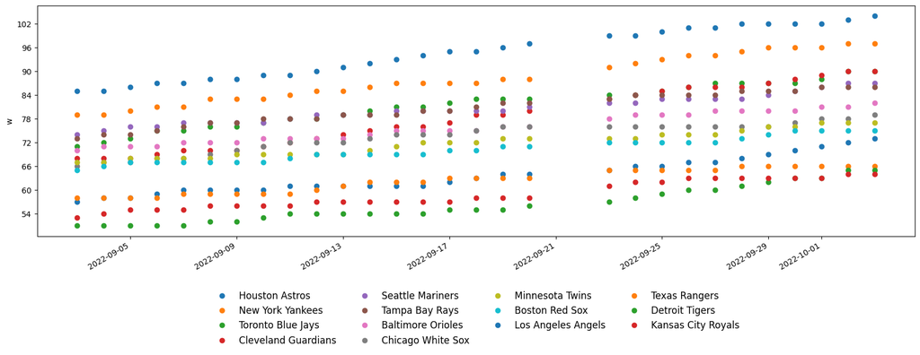

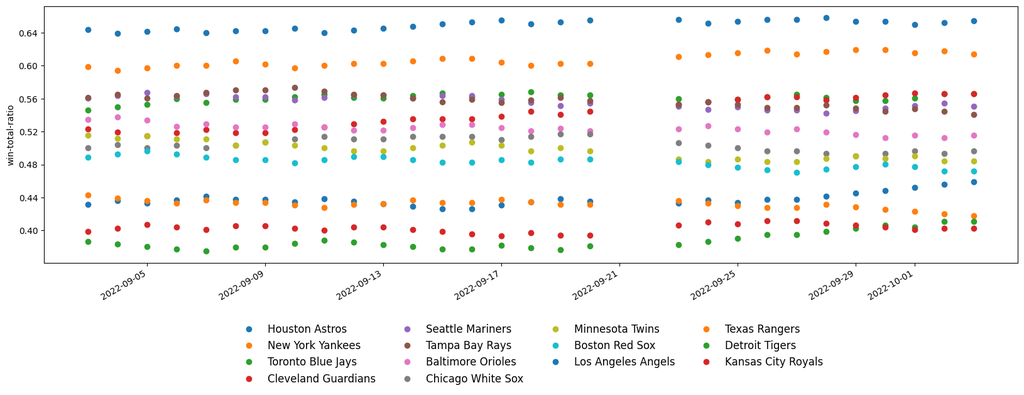

## Batting summary

Time series evolution of home runs and obp:

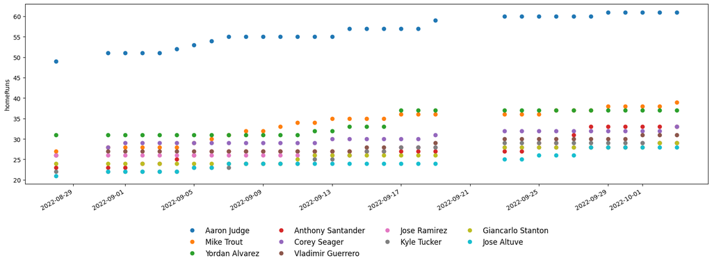

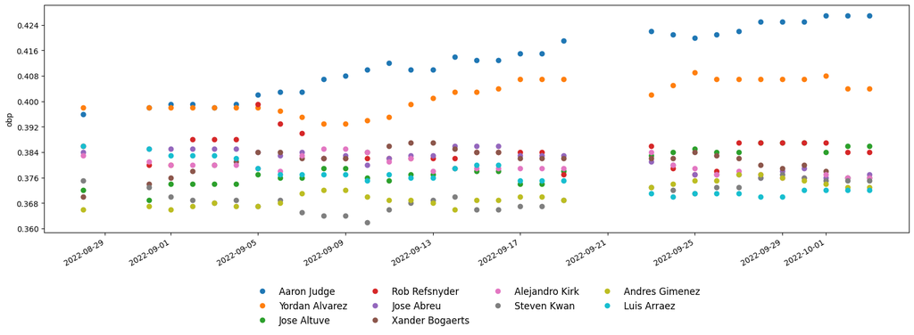

### Runs batted in (RBI)

Who is really 🔥💥 ?

|  | playername | rbiperplateAppearance |
| --- | --- | --- |
| 592450 | Aaron Judge | 0.189780 |
| 608070 | Jose Ramirez | 0.181820 |
| 643376 | Danny Jansen | 0.178420 |
| 670541 | Yordan Alvarez | 0.174550 |
| 663656 | Kyle Tucker | 0.172760 |
| 519317 | Giancarlo Stanton | 0.171170 |
| 660650 | Dermis Garcia | 0.169490 |
| 650391 | Eloy Jimenez | 0.166140 |
| 545361 | Mike Trout | 0.162890 |
| 521692 | Salvador Perez | 0.160680 |

And who is not 🧊🐢 ?

|  | playername | rbiperplateAppearance |
| --- | --- | --- |
| 681146 | Jonah Bride | 0.032430 |
| 668731 | Akil Baddoo | 0.043900 |
| 669352 | Bubba Thompson | 0.047340 |
| 664702 | Myles Straw | 0.051280 |
| 605353 | Vimael Machin | 0.051380 |
| 571466 | Tucker Barnhart | 0.053330 |
| 669397 | Nick Allen | 0.057320 |
| 622110 | Matt Duffy | 0.062760 |
| 641553 | Adam Engel | 0.063240 |
| 544725 | Leury Garcia | 0.063490 |

Who to watch? Biggest improvement from last week:

|  | playername | rbiperplateAppearancedifference |
| --- | --- | --- |
| 656811 | Ryan O'Hearn | 0.016220 |
| 669127 | Shea Langeliers | 0.015850 |
| 608701 | Rob Refsnyder | 0.014990 |
| 671277 | Luis Garcia | 0.012500 |
| 642350 | Jose Siri | 0.011780 |
| 571745 | Mitch Haniger | 0.010410 |
| 643376 | Danny Jansen | 0.010240 |
| 665506 | Cristian Pache | 0.010200 |
| 669397 | Nick Allen | 0.009540 |
| 664059 | Sam Haggerty | 0.009220 |

### Homeruns (HRs)

Who is really 🔥💥 ?

|  | playername | homeRunsperplateAppearance |
| --- | --- | --- |
| 592450 | Aaron Judge | 0.089050 |
| 545361 | Mike Trout | 0.080410 |
| 670541 | Yordan Alvarez | 0.067270 |
| 519317 | Giancarlo Stanton | 0.065320 |
| 663728 | Cal Raleigh | 0.064040 |
| 643376 | Danny Jansen | 0.062240 |
| 519203 | Anthony Rizzo | 0.059260 |
| 670623 | Isaac Paredes | 0.053760 |
| 467793 | Carlos Santana | 0.053760 |
| 623993 | Anthony Santander | 0.051890 |

And who is not 🧊🐢 ?

|  | playername | homeRunsperplateAppearance |
| --- | --- | --- |
| 444482 | David Peralta | 0.000000 |
| 543877 | Christian Vazquez | 0.000000 |
| 664702 | Myles Straw | 0.000000 |
| 571466 | Tucker Barnhart | 0.003330 |
| 605353 | Vimael Machin | 0.003950 |
| 624428 | Adam Frazier | 0.005080 |
| 681146 | Jonah Bride | 0.005410 |
| 669352 | Bubba Thompson | 0.005920 |
| 665482 | Gilberto Celestino | 0.005970 |
| 622682 | Victor Reyes | 0.006190 |

Who to watch? Biggest improvement from last week:

|  | playername | homeRunsperplateAppearancedifference |
| --- | --- | --- |
| 669127 | Shea Langeliers | 0.017250 |
| 672284 | Jarred Kelenic | 0.007220 |
| 571745 | Mitch Haniger | 0.005600 |
| 462101 | Elvis Andrus | 0.005470 |
| 669087 | Sam Huff | 0.004460 |
| 606992 | Eric Haase | 0.004340 |
| 642350 | Jose Siri | 0.004270 |
| 455139 | Robinson Chirinos | 0.004220 |
| 623993 | Anthony Santander | 0.004190 |
| 686681 | Michael Massey | 0.003800 |

### Strike-outs

Remember, unlike runs batted in and home-runs, strike-outs are bad! You cannot score runs if you do not put the ball in play!

Who is really 🔥💥 ?

|  | playername | strikeOutsperplateAppearance |
| --- | --- | --- |
| 650333 | Luis Arraez | 0.072148 |
| 664058 | David Fletcher | 0.074074 |
| 680757 | Steven Kwan | 0.092949 |
| 677551 | Wander Franco | 0.094675 |
| 672386 | Alejandro Kirk | 0.104673 |
| 650490 | Yandy Diaz | 0.106115 |
| 686469 | Vinnie Pasquantino | 0.115385 |
| 608324 | Alex Bregman | 0.119380 |
| 608070 | Jose Ramirez | 0.120715 |
| 643393 | Tony Kemp | 0.122263 |

And who is not 🧊🐢 ?

|  | playername | strikeOutsperplateAppearance |
| --- | --- | --- |
| 660650 | Dermis Garcia | 0.432203 |
| 666176 | Jo Adell | 0.375912 |
| 669127 | Shea Langeliers | 0.366197 |
| 663853 | Romy Gonzalez | 0.362745 |
| 672284 | Jarred Kelenic | 0.353659 |
| 676694 | Jake Meyers | 0.335526 |
| 666915 | Bobby Dalbec | 0.335227 |
| 642350 | Jose Siri | 0.331395 |
| 660271 | Shohei Ohtani | 0.326687 |
| 669352 | Bubba Thompson | 0.325444 |

Who to watch? Biggest improvement from last week:

|  | playername | strikeOutsperplateAppearancedifference |
| --- | --- | --- |
| 669127 | Shea Langeliers | -0.033800 |
| 668731 | Akil Baddoo | -0.020300 |
| 681987 | Nate Eaton | -0.019130 |
| 641820 | Trey Mancini | -0.015110 |
| 595909 | Jake Cave | -0.013400 |
| 669397 | Nick Allen | -0.010970 |
| 669087 | Sam Huff | -0.009600 |
| 686469 | Vinnie Pasquantino | -0.008650 |
| 606992 | Eric Haase | -0.008620 |
| 622110 | Matt Duffy | -0.007650 |

## Batting stats charts

A short explanation of the meaning of each chart, in order. If not explicitly mentioned, the variables are normalized by the number of plate appearances:

1. y-var: Base on Balls (i.e, walks), x-var: StrikeOuts - In theory, these variables should be negatively (i.e, inversely) correlated. Roughly speaking, aggressive batters which attack the ball thrown by the pitcher more often should walk fewer times because they are more likely to attack balls outside the strikezone, for which they would earn a walk;
2. y-var: Normalized ops (i.e, walks), x-var: Difference between StrikeOuts and Base On Balls - In theory, these variables should be inversely correlated, because to obtain a large on base percentage (obp) (recall ops = opb + slugging), the batter must avoid getting striked out. This chart is particularly useful to determine the elite players - those with an ops above league average and a negative difference between StrikeOuts and Base On Balls - i.e, the top left corner of the chart);
3. y-var: homeRuns, x-var: StrikeOuts - In theory, these variables should be positively correlated. Following 1., aggressive batters try to generate powerful contact with the ball more often. They will receive more homeRuns at the expense of more StrikeOuts. Elite players should be placed in the top half of the chart, towards the left.
4. y-var: totalBases , x-var: hits, both as a league z-score - These variables are proportional - to score a single, double or triple, the batter must hit the ball. On average, the batter will receive one base per hit. This chart is relevant to determine outliers. That is, Aaron Judge is an absolute freak!

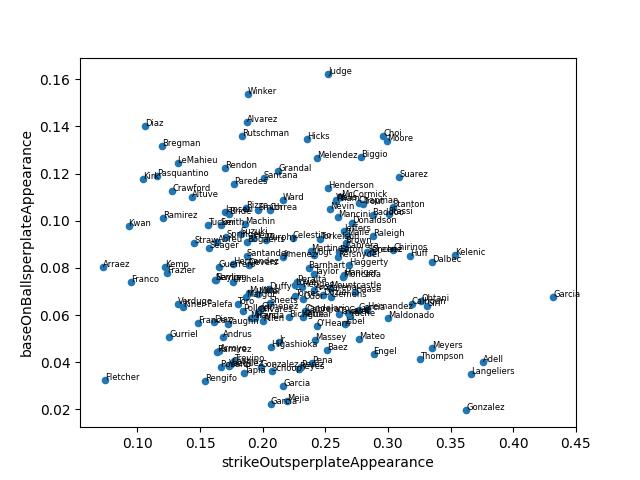

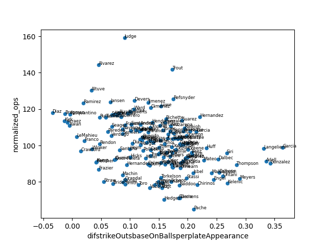

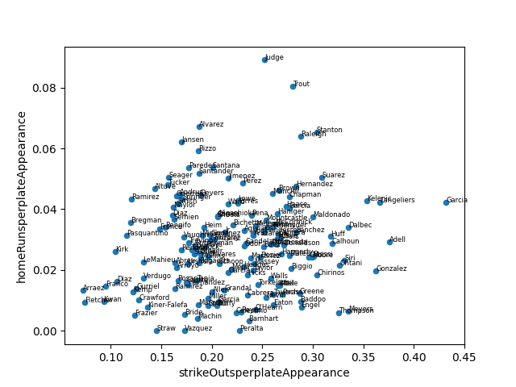

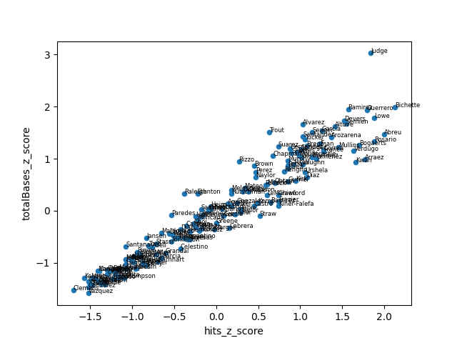